# What are the determinants of life expectancy?

### Changes in life expectancy by year: regions.

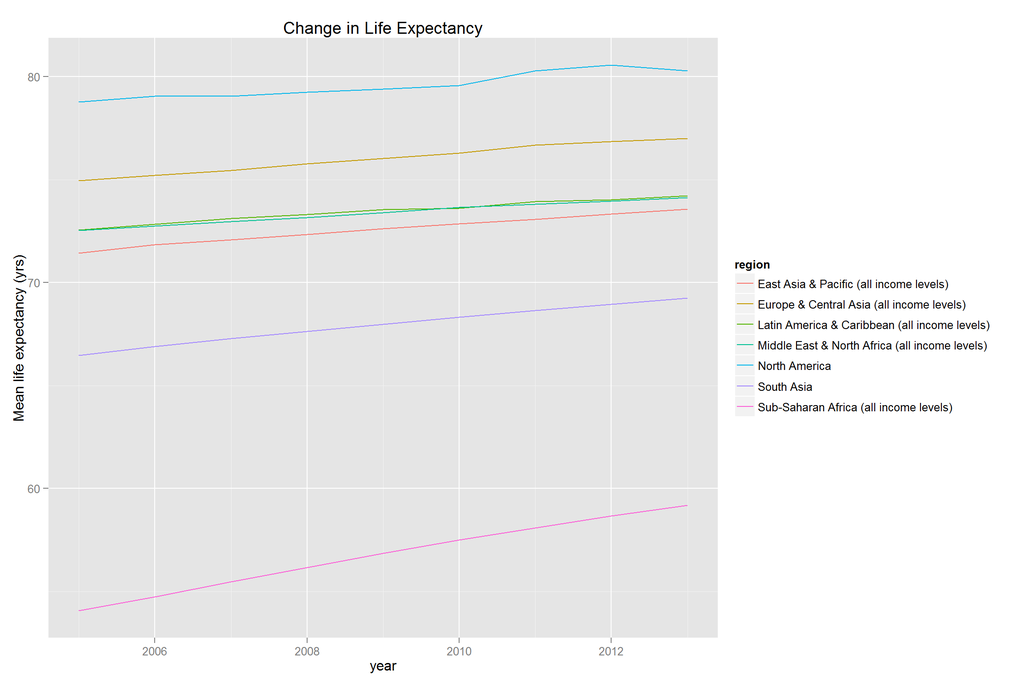

### Contructing a Model

Lastly, let’s fit a model to better quantify the effect of these indicators on life expectancy. Since we have panel data, I will construct a fixed effects model.

```
## Oneway (individual) effect Within Model
##
## Call:
## plm(formula = life.expect ~ I(log(gdp.pc)) + co2.em.pc + rural +
##     san.access.pct, data = df, model = "within", index = c("country",
##     "year"))
##
## Unbalanced Panel: n=180, T=1-7, N=1230
##
## Residuals :
##    Min. 1st Qu.  Median 3rd Qu.    Max.
## -5.0700 -0.3570 -0.0272  0.3190  5.3300
##
## Coefficients :
##                 Estimate Std. Error t-value  Pr(>|t|)
## I(log(gdp.pc))  3.749592   0.382323  9.8074 < 2.2e-16 ***
## co2.em.pc      -0.098987   0.030381 -3.2582  0.001157 **
## ruralTRUE      -0.018919   0.240885 -0.0785  0.937415
## san.access.pct  0.248110   0.021647 11.4614 < 2.2e-16 ***
## ---
## Signif. codes:  0 '***' 0.001 '**' 0.01 '*' 0.05 '.' 0.1 ' ' 1
##
## Total Sum of Squares:    1131.5
## Residual Sum of Squares: 788.27
## R-Squared:      0.30333
## Adj. R-Squared: 0.25796
## F-statistic: 113.859 on 4 and 1046 DF, p-value: < 2.22e-16
```

# Multivariate Analysis

### Talk about some of the relationships you observed in this part of the investigation. Were there features that strengthened each other in terms of looking at your features of interest?

Accounting for income differences across countries, the effect of `co2.em.pc` on `life.expect` was different. For High Income: non-OECD and upper middle income countries, `co2.em.pc` had a negative relationship with `life.expect` whereas for Low income and Lower middle income countries, the relationship was positive.

There is a stronger relationship between `health.expend.pc` and `life.expect` for non-rural countries than for rural countries. This could mean that rural countries spend less on health because they are in general lower income countries and we saw earlier how highly correlated `health.expend.pc` was to `gdp.pc` and `gdp.pc` to `life.expect`. It could also be that for every dollar spent on health in urban countries more people are covered than in rural countries. Therefore, at the same health expenditure level, the effect on life expectancy on urban countries is larger.

There is a similar trend when looking at the relationship between `health.expend.pc` and `life.expect` for tropical and not tropical countries. The explanation could be similar to the explanation for rural versus non-rural countries.

### Were there any interesting or surprising interactions between features?

When looking at the change in life expectancy over the years by region, life expectancy increased from 2005 to 2013 in all regions but the rate of increase was different across regions. Countries with initial lower life expectancy increased at a faster rate than countries with initial high life expectancy.

### Did you create any models with your dataset? Discuss the strengths and limitations of your model.

I created a fixed effects (FE) model to remove the effect of time-invariant characteristics of countries that I did not observe.

The coefficients estimated measure how much life expectancy changes overtime, on average per country, when the indicator increases by one unit. Estimates show that the effect of `gdp.pc` on `life.expect` is positive and statistically significant, as is the effect of `san.access.pct`. The effect of `rural` is not significant.

Unlike what we observed in the plot analysis, `co2.em.pc` has a negative effect on `life.expect`. In the previous plot analysis, it was difficult to elucidate the relationship between `co2.em.pc` and `life.expect` because of great heterogeneity in our observations. The FE model allows us to control for characteristics that are inherent to each country.

The FE model allows us to control for unobserved heterogeneity which given our dataset, is an issue of concern. Some limitations of the FE model is that time-invariant effects are not identified, so for instance, the rural coefficient might not be correctly estimated.

# Final Plots and Summary

### Plot One

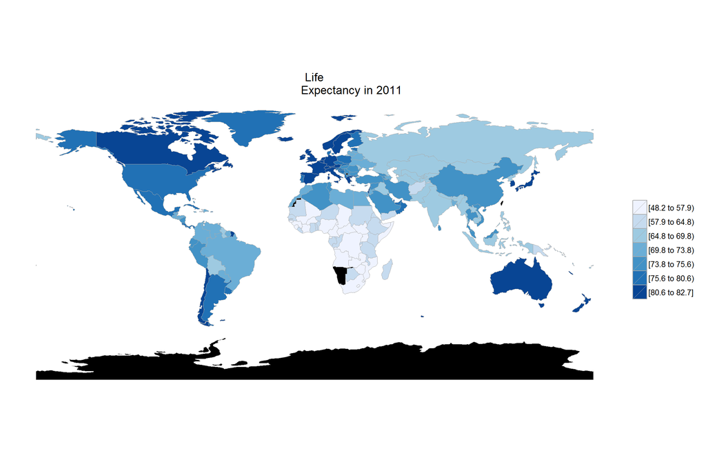

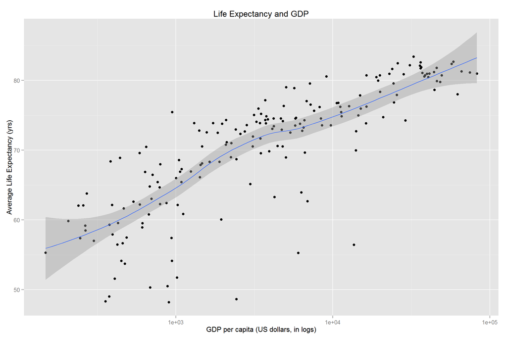

### Description One

Plot one is compromised of two parts. The first plot shows a choroplethr map where countries are colored by their value of average life expectancy. This value was categorized in 7 different intervals. There is missing data for Namibia and only data for 2011 was considered. The majority of countries with the lowest life expectancy, from 48.2 to 64.8, are in Sub-Saharan Africa. Countries with life expectancy between 64.8 and 73.8 are in Latin America and some parts of Asia. Countries with the highest life expectancy are in Europe, North America, and Oceania. Because this map appeared to show a correlation between economic development and life expectancy, plot one part II is a scatter plot of average life expectancy and GDP per capita for the year 2011. Here, I did a log transformation of GDP per capita and added a trend line with a 95 % confidence interval. The line is close to linear and has a positive slope, indicating a positive relationship between GDP and life expectancy and in line with the results in the choroplethr map. Countries with lower GDP per capita have lower values of life expectancy.

### Plot Two

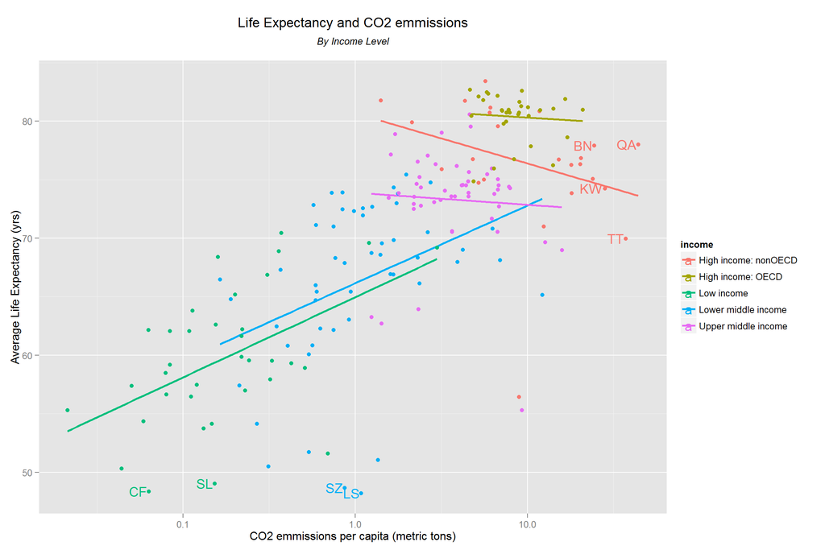

### Plot Three

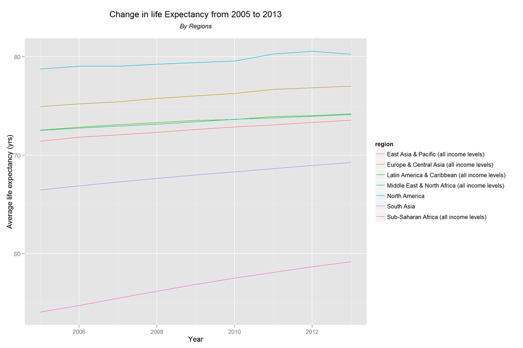

### Description Three

This figure shows a line with the change in average life expectancy from 2005 to 2013. Different colors in the plot indicate different regions. The plot shows that average life expectancy grew for all regions but at different rates. The highest growth rate was in countries in the Sub-Saharan Africa region followed by countries in South Asia. Next, were countries in Middle East and North Africa, Latin America and East Asia and the Pacific. Lastly, European countries appear to have a higher growth rate than North American countries.

# Reflection

In this study we analyzed what where the determinants of average life expectancy in countries across the world. We mainly explored indicators related to income levels of countries or indicators highly affected by income such as access to sanitation. We also looked at differences among genders, rural and tropical countries. Lastly, we also looked at the change in life expectancy from 2005 to 2013.

It is possible to further explore this dataset by looking at more disaggregated data. There are probably large differences in life expectancy among countries. This could also help capture differences between rural and urban population’s life expectancy and better capture differences of the effect of CO2 emissions. It would also be interesting to see how countries’ different health systems affect life expectancy.